# Reproducible Research

### Peer Assessment I

Using **knitr** in **R Markdown** to produce document which is answers the assignment questions.  
Assuming “activity.csv” file is in the same directory as the .Rmd file

**Load data and required packages.**

```r
suppressMessages(library(ggthemes))
suppressMessages(library(ggplot2))
activity <- read.csv("activity.csv")
activity$date<-as.Date(activity$date)
```

**Project Requirement 1: What is mean total number of steps taken per day?**

```r
# Aggregate steps group by date, ignore NA values.
steps_per_day <- aggregate(steps ~ date, data = activity, FUN = sum, na.rm=TRUE)
mean_steps_per_day <- round(mean(steps_per_day$steps))
median_steps_per_day <- round(median(steps_per_day$steps))
```

Mean steps per day = 10766  
Median steps per day = 10765

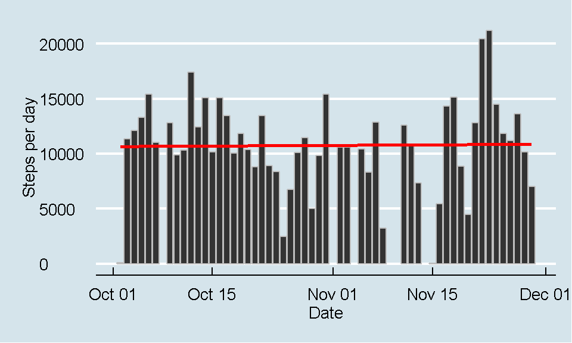

```r
ggplot(steps_per_day, aes(x=date,y=steps)) +
    geom_bar(stat = "identity", position=position_dodge(),color="grey") +
    stat_smooth(method="lm", se=FALSE, colour = "red", size = 1) +
    theme_economist() + scale_colour_economist() +
    xlab("Date")  + ylab("Steps per day")
```

**Project Requirement 2: What is the average daily activity pattern?**

```r
activity_cc <- na.omit(activity)
steps_per_interval <- aggregate(steps ~ interval, data=activity_cc,FUN=mean)
max_steps_interval <- round(max(steps_per_interval$steps))
interval_max_steps <- steps_per_interval$interval[which.max(steps_per_interval$steps)]
```

Reporting interval 835 having maximum activity.  
Average of 206 steps taken during this interval.

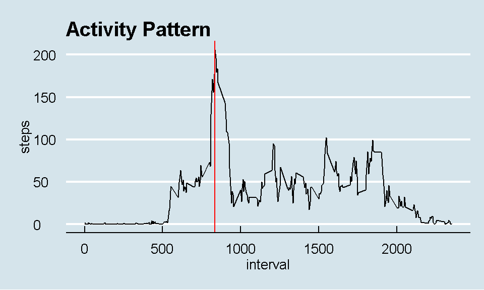

```r
ggplot(steps_per_interval, aes(x=interval, y=steps)) +
    geom_line(stat="identity") + theme_economist() + scale_colour_economist() +
    geom_vline(xintercept=steps_per_interval$interval[which.max(steps_per_interval$steps)] ,color="red") +
    labs(title="Activity Pattern",fontsize=1)
```

**Project Requirement 3: Imputing missing values**  
I have tried two methods of inputing the missing values.  
One taking the mean of each interval and substituting the missing value with relevent interval.  
Second, the mean of none missing value steps taken.  
Both resulted in identical answers, so I am using the easier of the two, the second method.

```r
activity2 <- activity
activity2$steps[is.na(activity2$steps)] <- mean(na.omit(activity2$steps))
steps_per_day2 <- aggregate(steps ~ date, data=activity2, FUN=sum)
mean_steps_per_day2 <- round(mean(steps_per_day2$steps))
median_steps_per_day2 <- round(median(steps_per_day2$steps))
```

Mean steps per day after imputing NA’s = 10766  
Median steps per day after imputing NA’s = 10766

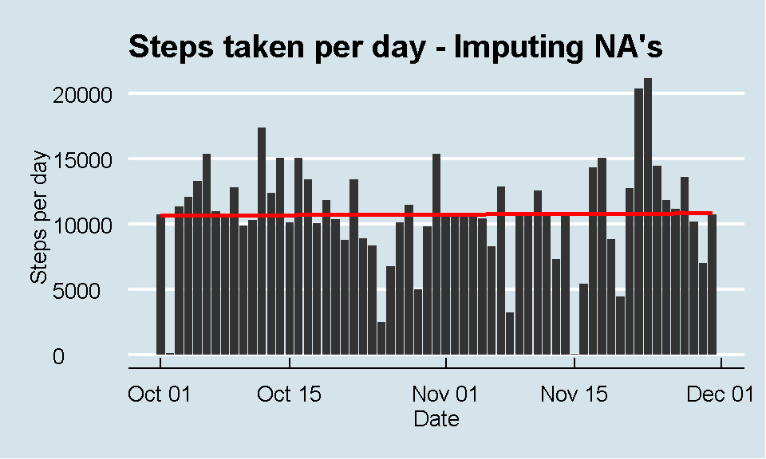

```r
ggplot(steps_per_day2, aes(x=date,y=steps)) +
    geom_bar(stat = "identity", position=position_dodge()) +
    stat_smooth(method="lm", se=FALSE, colour = "red", size = 1) +
    theme_economist() + scale_colour_economist() +
    xlab("Date")  + ylab("Steps per day") +
    labs(title="Steps taken per day - Imputing NA's")
```

**Project Requirement 4: Differences in activity patterns between weekdays and weekends**

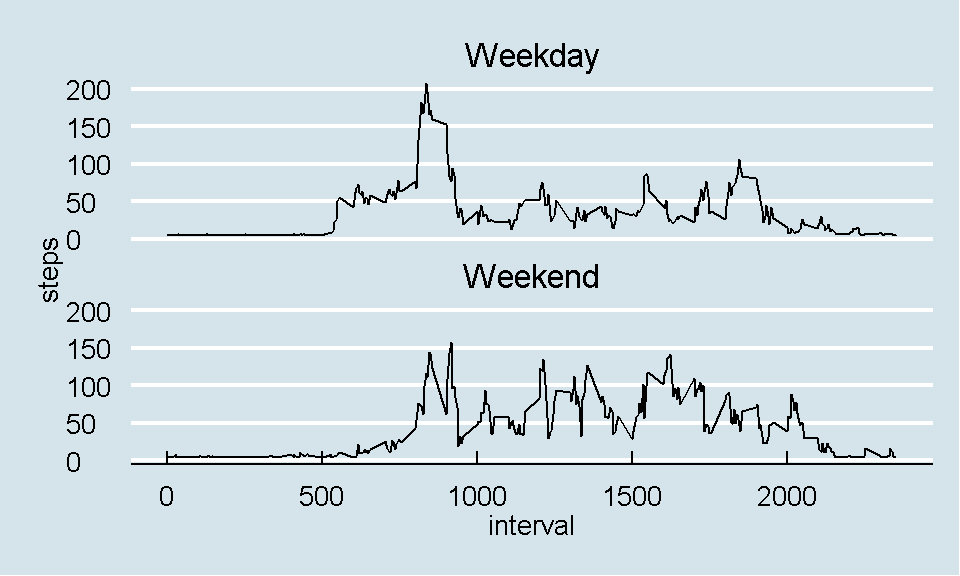

```r
activity2$day[weekdays(as.Date(activity2$date)) %in% c("Saturday", "Sunday")] <- "Weekend"
activity2$day[!weekdays(as.Date(activity2$date)) %in% c("Saturday", "Sunday")] <- "Weekday"
activity2[, 4] <- as.factor(activity2[, 4])
steps.new <- aggregate(steps ~ interval + day, data=activity2, FUN=mean)
ggplot(steps.new, aes(x=interval, y=steps, group=1)) +
    geom_line() + facet_wrap(~ day, ncol=1) +
    theme_economist() + scale_colour_economist()
```

End of exercise.